# Coursera Practical Machine Learning Prediction Assignment: Activity Proficiency

Christopher Marth

February 13, 2016

# Executive Summary

In the following analysis we produce a predictive model to assess the proficiency of subjects when it comes to peforming certain fitness activities. Data for this analysis came from the Human Activity Recognition project, which is part of Groupware Technologies. Using a standard data set made available from the source, we apply fundamental data analysis tasks to arrive at a set of predictive models that can be used to assess activity proficiency. Analysis includes commentary of how and why each decision in the analysis was made for pedagogical purposes. This analysis was performed as part of the course assignment for the Coursera Practical Machine Learning course assignment.

# Getting and Cleaning Data

The original data used for the analysis was made available here: http://groupware.les.inf.puc-rio.br/har. Training and testing sets for modeling purposes where also provided at the following locations: Training set - https://d396qusza40orc.cloudfront.net/predmachlearn/pml-training.csv; Testing set - https://d396qusza40orc.cloudfront.net/predmachlearn/pml-testing.csv. After acquiring the data, a basic data cleansing approach was employed to produce an appropriate training data set to be used for further analysis.

First, any features that had mostly missing data where removed. This eliminated 100 of the 160 features in the original data set.

```r
# Load in the data
testing = read.csv("/Users/racerx/Projects/coursera/machineLearning/pml-testing.csv")
training = read.csv("/Users/racerx/Projects/coursera/machineLearning/pml-training.csv")

# Clean up the data - Remove any columns that are mostly NA or empty
cleaned <- training[,colSums(is.na(training)) < nrow(training)*0.9]
cleaned <- cleaned[,colSums(cleaned == "") < nrow(training)*0.9]
```

Next, near-zero covariates were removed from the data, and there was only one: “new_window”

```r
# Look for zero covariates
library(caret)
set.seed(32433)
nsv <- nearZeroVar(cleaned,saveMetrics=TRUE)
nsv
```

```
##                      freqRatio percentUnique zeroVar   nzv
## X                     1.000000  100.00000000   FALSE FALSE
## user_name             1.100679    0.03057792   FALSE FALSE
## raw_timestamp_part_1  1.000000    4.26562022   FALSE FALSE
## raw_timestamp_part_2  1.000000   85.53154622   FALSE FALSE
## cvtd_timestamp        1.000668    0.10192641   FALSE FALSE
## new_window           47.330049    0.01019264   FALSE  TRUE
## num_window            1.000000    4.37264295   FALSE FALSE
## roll_belt             1.101904    6.77810621   FALSE FALSE
## pitch_belt            1.036082    9.37722964   FALSE FALSE
## yaw_belt              1.058480    9.97349913   FALSE FALSE
## total_accel_belt      1.063160    0.14779329   FALSE FALSE
## gyros_belt_x          1.058651    0.71348486   FALSE FALSE
## gyros_belt_y          1.144000    0.35164611   FALSE FALSE
## gyros_belt_z          1.066214    0.86127816   FALSE FALSE
## accel_belt_x          1.055412    0.83579655   FALSE FALSE
## accel_belt_y          1.113725    0.72877383   FALSE FALSE
## accel_belt_z          1.078767    1.52379982   FALSE FALSE
## magnet_belt_x         1.090141    1.66649679   FALSE FALSE
## magnet_belt_y         1.099688    1.51870350   FALSE FALSE
## magnet_belt_z         1.006369    2.32901845   FALSE FALSE
## roll_arm             52.338462   13.52563449   FALSE FALSE
## pitch_arm            87.256410   15.73234125   FALSE FALSE
## yaw_arm              33.029126   14.65701763   FALSE FALSE
## total_accel_arm       1.024526    0.33635715   FALSE FALSE
## gyros_arm_x           1.015504    3.27693405   FALSE FALSE
## gyros_arm_y           1.454369    1.91621649   FALSE FALSE
## gyros_arm_z           1.110687    1.26388747   FALSE FALSE
## accel_arm_x           1.017341    3.95984099   FALSE FALSE
## accel_arm_y           1.140187    2.73672409   FALSE FALSE
## accel_arm_z           1.128000    4.03628580   FALSE FALSE
## magnet_arm_x          1.000000    6.82397309   FALSE FALSE
## magnet_arm_y          1.056818    4.44399144   FALSE FALSE
## magnet_arm_z          1.036364    6.44684538   FALSE FALSE
## roll_dumbbell         1.022388   84.20650290   FALSE FALSE
## pitch_dumbbell        2.277372   81.74498012   FALSE FALSE
## yaw_dumbbell          1.132231   83.48282540   FALSE FALSE
## total_accel_dumbbell  1.072634    0.21914178   FALSE FALSE
## gyros_dumbbell_x      1.003268    1.22821323   FALSE FALSE
## gyros_dumbbell_y      1.264957    1.41677709   FALSE FALSE
## gyros_dumbbell_z      1.060100    1.04984201   FALSE FALSE
## accel_dumbbell_x      1.018018    2.16593619   FALSE FALSE
## accel_dumbbell_y      1.053061    2.37488533   FALSE FALSE
## accel_dumbbell_z      1.133333    2.08949139   FALSE FALSE
## magnet_dumbbell_x     1.098266    5.74864948   FALSE FALSE
## magnet_dumbbell_y     1.197740    4.30129447   FALSE FALSE
## magnet_dumbbell_z     1.020833    3.44511263   FALSE FALSE
## roll_forearm         11.589286   11.08959331   FALSE FALSE
## pitch_forearm        65.983051   14.85577413   FALSE FALSE
## yaw_forearm          15.322835   10.14677403   FALSE FALSE
## total_accel_forearm   1.128928    0.35674243   FALSE FALSE
## gyros_forearm_x       1.059273    1.51870350   FALSE FALSE
## gyros_forearm_y       1.036554    3.77637346   FALSE FALSE
## gyros_forearm_z       1.122917    1.56457038   FALSE FALSE
## accel_forearm_x       1.126437    4.04647844   FALSE FALSE
## accel_forearm_y       1.059406    5.11160942   FALSE FALSE
## accel_forearm_z       1.006250    2.95586586   FALSE FALSE
## magnet_forearm_x      1.012346    7.76679238   FALSE FALSE
## magnet_forearm_y      1.246914    9.54031189   FALSE FALSE
## magnet_forearm_z      1.000000    8.57710733   FALSE FALSE
## classe                1.469581    0.02548160   FALSE FALSE
```

```r
cleaned$new_window <- NULL
```

Finally, it was decided to remove the feature ‘X’ as it was merely an index variable for each case number and would add no insight to the analysis.

```r
cleaned$X <- NULL
```

# Exploratory Analysis

With the data set cleaned, exploratory analysis was performed in an attempt to gain an understanding of how the predictors might impact the outcome in question, specifically the variable “classe”. Given the large number of predictors, and the brevity we are trying to achieve with this report, only a small subset of the exploration is shown here. All exploration was done after first dividing the cleaned training set into additional training and test subsets in order to allow for cross-validation later on in the analysis.

```r
inTrain <- createDataPartition(y=cleaned$classe, p=0.10, list=FALSE)
cleaned_train <- cleaned[inTrain,]
cleaned_test <- cleaned[-inTrain,]
```

From there we perform basic exploratory analysis. An example of some of the analysis is given here:

```r
# Get a summary of the data set to get basic description for each predictor
summary(cleaned_train)
```

```
##     user_name   raw_timestamp_part_1 raw_timestamp_part_2
##  adelmo  :391   Min.   :1.322e+09    Min.   :   328
##  carlitos:304   1st Qu.:1.323e+09    1st Qu.:255875
##  charles :372   Median :1.323e+09    Median :507500
##  eurico  :307   Mean   :1.323e+09    Mean   :503546
##  jeremy  :312   3rd Qu.:1.323e+09    3rd Qu.:748587
##  pedro   :278   Max.   :1.323e+09    Max.   :998688
##
##           cvtd_timestamp   num_window      roll_belt
##  28/11/2011 14:14: 160   Min.   :  1.0   Min.   :-27.00
##  05/12/2011 14:23: 150   1st Qu.:209.8   1st Qu.:  1.10
##  05/12/2011 11:25: 143   Median :418.5   Median :115.00
##  05/12/2011 11:24: 140   Mean   :430.6   Mean   : 66.82
##  02/12/2011 13:33: 139   3rd Qu.:654.2   3rd Qu.:123.00
##  30/11/2011 17:11: 139   Max.   :863.0   Max.   :161.00
##  (Other)         :1093
##    pitch_belt          yaw_belt        total_accel_belt  gyros_belt_x
##  Min.   :-53.5000   Min.   :-179.000   Min.   : 1.00    Min.   :-0.96000
##  1st Qu.:  1.7425   1st Qu.: -88.300   1st Qu.: 3.00    1st Qu.:-0.05000
##  Median :  5.3600   Median :  -7.705   Median :17.00    Median : 0.03000
##  Mean   :  0.4595   Mean   :  -9.354   Mean   :11.63    Mean   :-0.01328
##  3rd Qu.: 15.7000   3rd Qu.:  15.700   3rd Qu.:18.00    3rd Qu.: 0.11000
##  Max.   : 59.0000   Max.   : 179.000   Max.   :28.00    Max.   : 2.02000
##
##   gyros_belt_y       gyros_belt_z      accel_belt_x      accel_belt_y
##  Min.   :-0.40000   Min.   :-1.3000   Min.   :-81.000   Min.   :-36.00
##  1st Qu.: 0.00000   1st Qu.:-0.2000   1st Qu.:-21.000   1st Qu.:  3.00
##  Median : 0.02000   Median :-0.1100   Median :-15.000   Median : 41.00
##  Mean   : 0.04137   Mean   :-0.1362   Mean   : -5.878   Mean   : 31.18
##  3rd Qu.: 0.11000   3rd Qu.:-0.0200   3rd Qu.: -5.000   3rd Qu.: 61.00
##  Max.   : 0.63000   Max.   : 1.6200   Max.   : 76.000   Max.   : 90.00
##
##   accel_belt_z     magnet_belt_x    magnet_belt_y   magnet_belt_z
##  Min.   :-266.00   Min.   :-49.00   Min.   :363.0   Min.   :-612.0
##  1st Qu.:-163.00   1st Qu.:  9.00   1st Qu.:580.0   1st Qu.:-376.0
##  Median :-154.00   Median : 33.00   Median :601.0   Median :-321.0
##  Mean   : -76.75   Mean   : 54.96   Mean   :592.5   Mean   :-347.5
##  3rd Qu.:  27.00   3rd Qu.: 57.00   3rd Qu.:610.0   3rd Qu.:-306.0
##  Max.   :  89.00   Max.   :471.00   Max.   :657.0   Max.   : 279.0
##
```

[output cut: 73 more lines]

```
##  Min.   :-391.00   Min.   :-1270.00   Min.   :-849.0   Min.   :-957.0
##  1st Qu.:-182.00   1st Qu.: -614.00   1st Qu.: -11.5   1st Qu.: 175.0
##  Median : -33.00   Median : -360.00   Median : 588.5   Median : 501.5
##  Mean   : -54.39   Mean   : -306.81   Mean   : 372.0   Mean   : 391.1
##  3rd Qu.:  26.00   3rd Qu.:  -57.75   3rd Qu.: 730.0   3rd Qu.: 650.2
##  Max.   : 285.00   Max.   :  661.00   Max.   :1440.0   Max.   :1050.0
##
##  classe
##  A:558
##  B:380
##  C:343
##  D:322
##  E:361
##
##
```

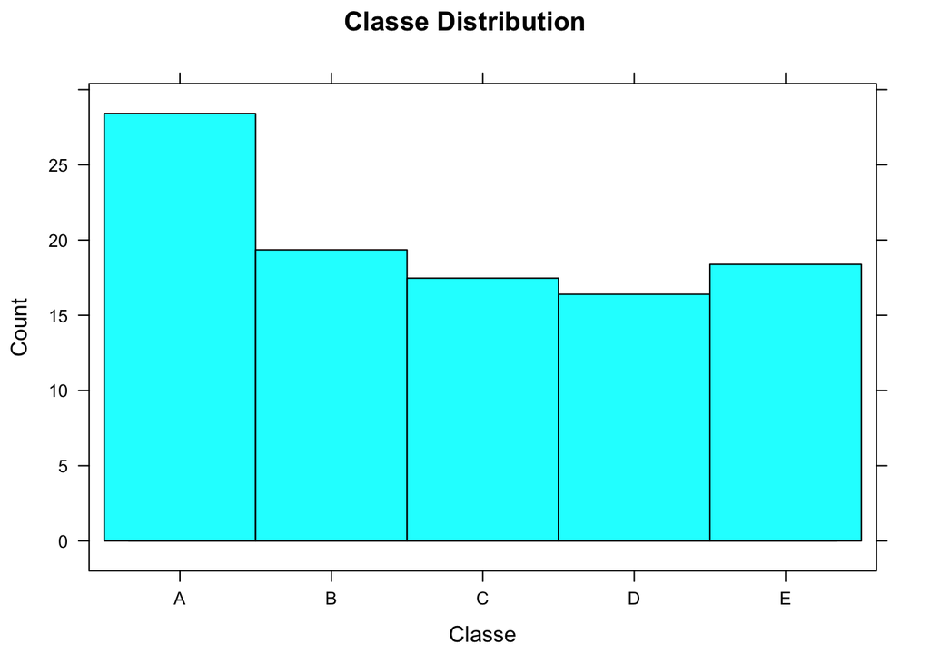

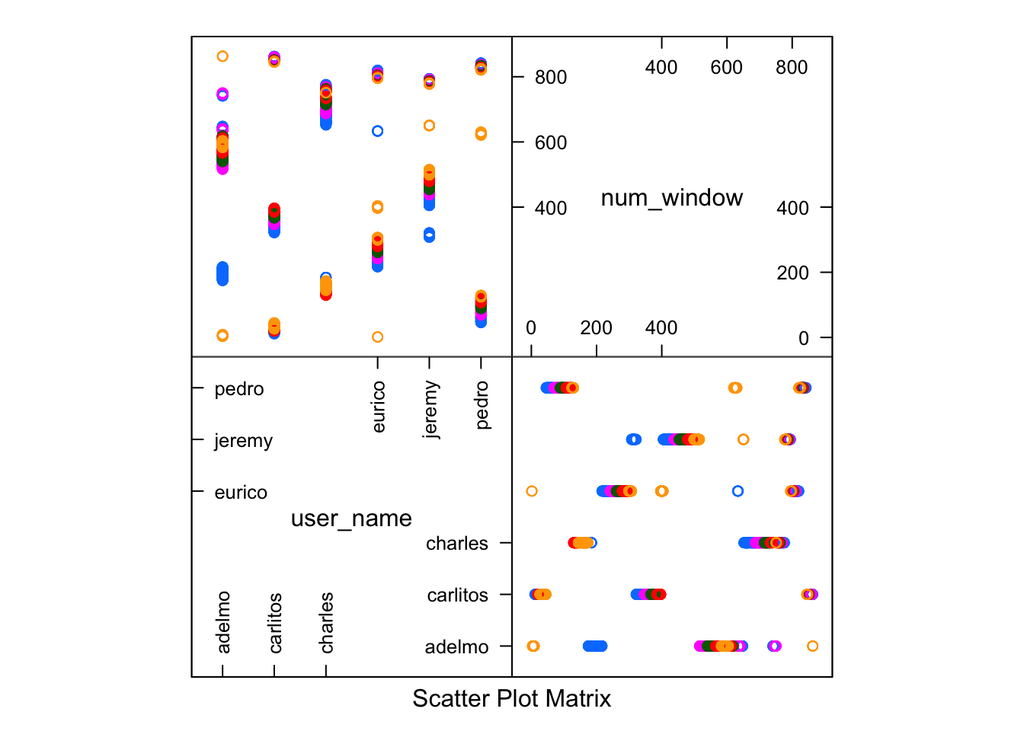

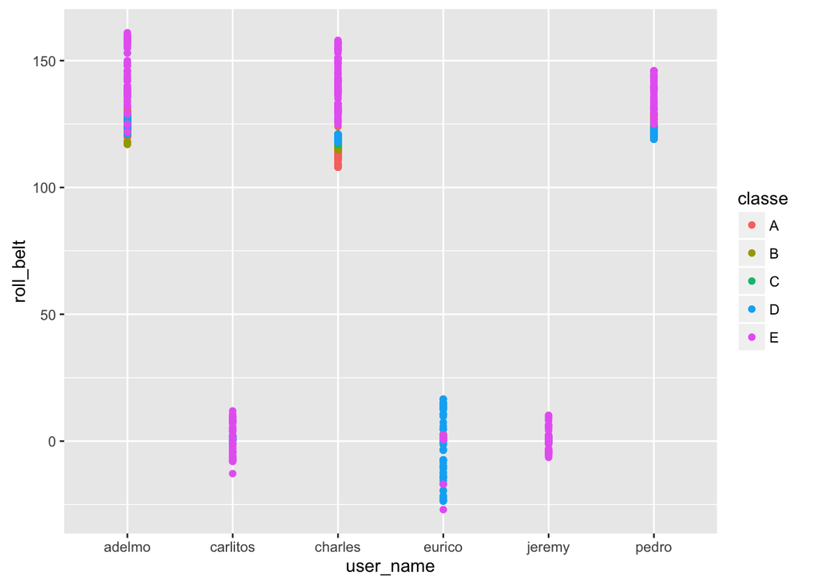

# Predictive Model Analysis

## Random Forest with all predictors

The initial approach to create a predictive model was to employ a random forest predicting the outcome variable “classe” using the complete set of predictors. A random forest was chosen due to its ability to predict with with high accuracy with a large number of predictors with potentially non-linear relationships to the outcome variable. Prediction results for the training subset derived from the cleaned training set are shown first which are then cross-validated against the test subset.

```r
modFit <- train(classe~.,method="rf",data=cleaned_train)
## Prediction Accuracy on the training set
prediction_train <- predict(modFit, cleaned_train)
correct_train <- prediction_train == cleaned_train$classe
accuracy_train <- length(prediction_train[correct])/length(prediction_train)
accuracy_train
```

[output not shown]

```r
confusionMatrix(cleaned_train$classe, predict(modFit,cleaned_train))
```

[output not shown]

```r
# Prediction Accuracy on the test set
prediction_test <- predict(modFit, cleaned_test)
correct_test <- prediction_test == cleaned_test$classe
accuracy_test <- length(prediction_test[correct,])/length(prediction_test)
accuracy_test
```

[output not shown]

```r
confusionMatrix(cleaned_test$classe, predict(modFit,cleaned_test))
```

[output not shown]

Since this level of accuracy was acceptable to meet the requirements for the assignment quiz (80% accuracy required), this model was used to predict the outcome for the original test set for that purpose.

## Principle Components Analysis (PCA)

In an attempt to reduce the number of predictors, and thus allow the creation of the predictive model to happen much faster (we had no performance requirement for the model, but anecdotally it did take a long time to solve for the original random forest model using all predictors), we applied PCA to pre-process the training. The details of that analysis are shown here:

```r
modFitPca <- train(classe~.,method="rf", preProcess="pca", data=cleaned_train)
```

```r
prediction_test <- predict(modFitPca, cleaned_test)
correct_test <- prediction_test == cleaned_test$classe
accuracy_test <- length(prediction_test[correct_test])/length(prediction_test)
accuracy_test
```

[output not shown]

```r
confusionMatrix(cleaned_test$classe, predict(modFitPca,cleaned_test))
```

```
## Confusion Matrix and Statistics
##
##           Reference
## Prediction    A    B    C    D    E
##          A 4784  135  103    0    0
##          B  284 2940  185    8    0
##          C   10  238 2716  115    0
##          D    0   30  217 2599   48
##          E    0    0   13  175 3058
##
## Overall Statistics
##
##                Accuracy : 0.9116
##                  95% CI : (0.9073, 0.9157)
##     No Information Rate : 0.2876
##     P-Value [Acc > NIR] : < 2.2e-16
##
##                   Kappa : 0.8882
##  Mcnemar's Test P-Value : NA
##
## Statistics by Class:
##
##                      Class: A Class: B Class: C Class: D Class: E
## Sensitivity            0.9421   0.8794   0.8398   0.8971   0.9845
## Specificity            0.9811   0.9667   0.9748   0.9800   0.9871
## Pos Pred Value         0.9526   0.8604   0.8821   0.8981   0.9421
## Neg Pred Value         0.9767   0.9717   0.9645   0.9798   0.9967
## Prevalence             0.2876   0.1893   0.1831   0.1641   0.1759
## Detection Rate         0.2709   0.1665   0.1538   0.1472   0.1732
## Detection Prevalence   0.2844   0.1935   0.1744   0.1639   0.1838
## Balanced Accuracy      0.9616   0.9231   0.9073   0.9386   0.9858
```

# Conclusion

Either of the predictive models generated in the analysis could mostly be used to predict “classe” in the general case. If, however, performance requirements are such that speed of prediction is important, the PCA model would be a better choice.